# Lab11

Lauren Gregg, Katie Jiang, Ryan Marizza, Chris He

4/06/2018

# First Three Letters of Names

## Katie

```r
sum(str_count(babynames$name,"Kat"))
```

```
## [1] 8163
```

```r
sum(str_count(babynames$name,"kat"))
```

```
## [1] 309
```

ratio of “Kat” = 0.96

## Ryan

```r
Ryan_ratio = sum(str_count(babynames$name,"Rya"))/(sum(str_count(babynames$name,"Rya"))+sum(str_count(babynames$name,"rya")))
Ryan_ratio
```

```
## [1] 0.1370968
```

## Chris

```r
Chris<-filter(babynames,str_detect(babynames$name,"^Chr"))
chris<-filter(babynames, str_detect(babynames$name,"chr"))
chrtotal<-sum(chris$n)
Chrtotal<-sum(Chris$n)
Chrcomparetototal<-Chrtotal/(chrtotal+Chrtotal)
Chrcomparetototal
```

```
## [1] 0.9994246
```

## Lauren

```r
countLG1 <- sum(str_count(babynames$name,"^Lau"))
countLG2 <- sum(str_count(babynames$name,"lau"))
ratioLG <- countLG1 / (countLG1 + countLG2)
ratioLG
```

```
## [1] 0.6399474
```

## Plot

```r
Ryan_ratio = sum(str_count(babynames$name,"^Rya"))/(sum(str_count(babynames$name,"^Rya"))+sum(str_count(babynames$name,"rya")))
Lauren_ratio = sum(str_count(babynames$name,"^Lau"))/(sum(str_count(babynames$name,"^Lau"))+sum(str_count(babynames$name,"lau")))
Katie_ratio = sum(str_count(babynames$name,"^Kat"))/(sum(str_count(babynames$name,"^Kat"))+sum(str_count(babynames$name,"kat")))
Chris_ratio = sum(str_count(babynames$name,"^Chr"))/(sum(str_count(babynames$name,"^Chr"))+sum(str_count(babynames$name,"chr")))


data_ryan <- babynames %>% group_by(year) %>%
  summarise(prop_rya = sum(str_count(name,"Rya"))/sum(str_count(name,"")))
data_lauren <- babynames %>% group_by(year) %>%
  summarise(prop_lau = sum(str_count(name,"Lau"))/sum(str_count(name,"")))
data_katie <- babynames %>% group_by(year) %>%
  summarise(prop_kat = sum(str_count(name,"Kat"))/sum(str_count(name,"")))
data_chris <- babynames %>% group_by(year) %>%
  summarise(prop_chr = sum(str_count(name,"Chr"))/sum(str_count(name,"")))
```

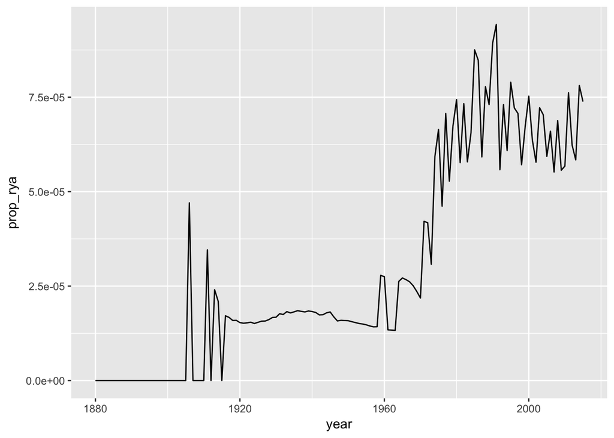

```r
ggplot(data = data_ryan,aes(x=year,y=prop_rya))+
  geom_line()
```

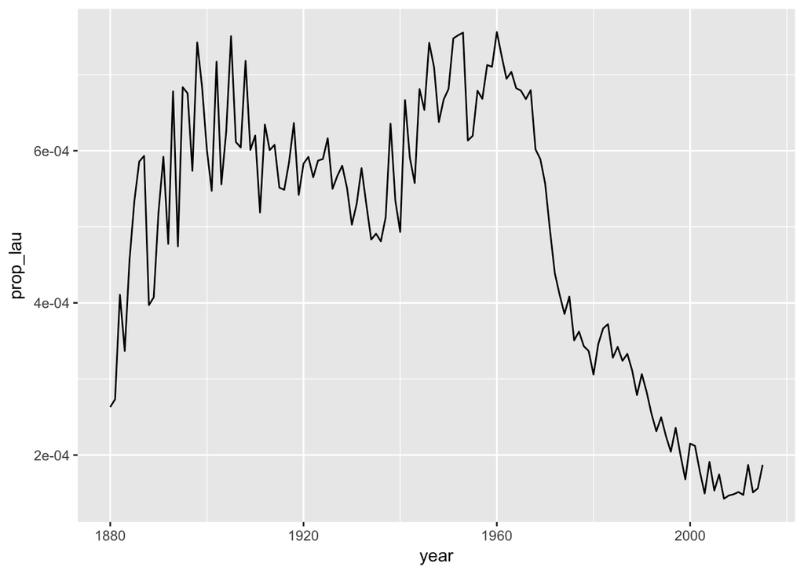

```r
ggplot(data = data_lauren,aes(x=year,y=prop_lau))+
  geom_line()
```

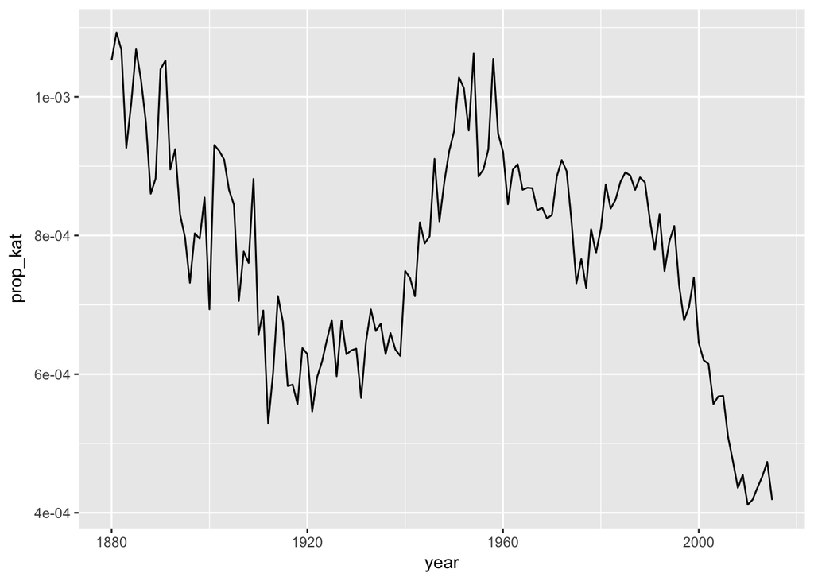

```r
ggplot(data = data_katie,aes(x=year,y=prop_kat))+
  geom_line()
```

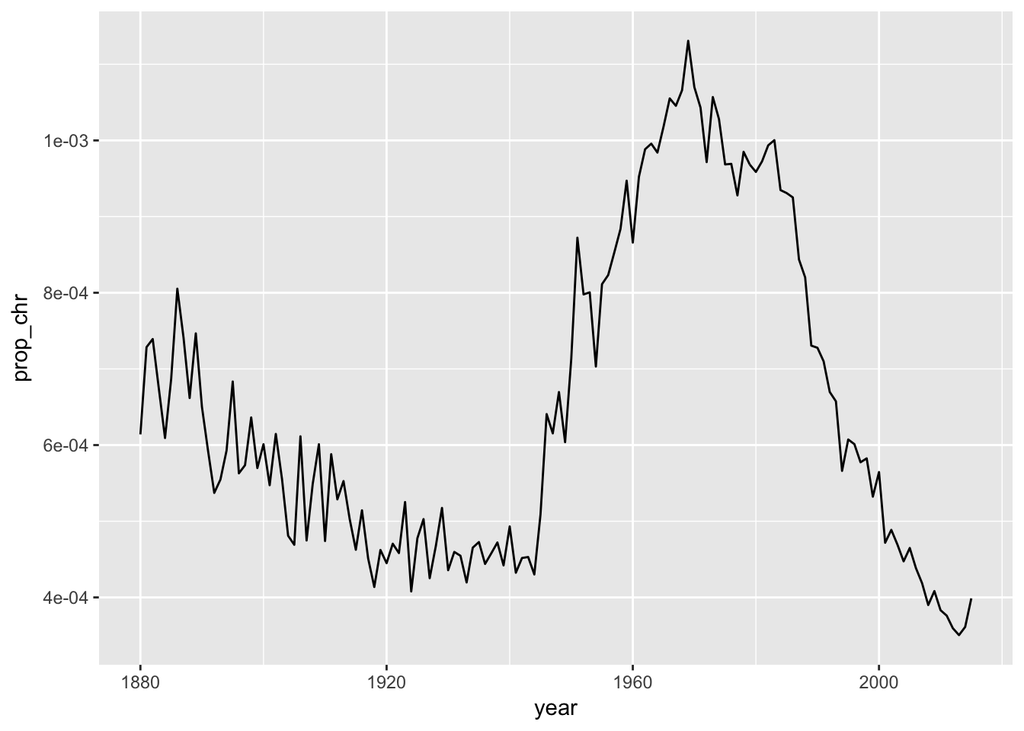

```r
ggplot(data = data_chris,aes(x=year,y=prop_chr))+
  geom_line()
```

# Ariel and Rachel regexs

```r
Rach1973 <- filter(babynames,str_detect(babynames$name,"^Rach[:lower:]*l$|^Raych[:lower:]*l$"),year==1973,sex =="F")%>% count()
Rach1973
```

```
## # A tibble: 1 x 1
##      nn
##   <int>
## 1     7
```

```r
Rach1988 <- filter(babynames,str_detect(babynames$name,"^Rach[:lower:]*l$|^Raych[:lower:]*l$"),year==1988,sex =="F")%>% count()
Rach1988
```

```
## # A tibble: 1 x 1
##      nn
##   <int>
## 1     9
```

```r
Rach1990 <- filter(babynames,str_detect(babynames$name,"^Rach[:lower:]*l$|^Raych[:lower:]*l$"),year==1990,sex =="F")%>% count()
Rach1990
```

```
## # A tibble: 1 x 1
##      nn
##   <int>
## 1     8
```

```r
A.count1973 <- filter(babynames,str_count(babynames$name,"Ar[iy]+.l+[^ayi]$|Arial|Ariale|Arialle"),year==1973,sex=="F") %>% count() #2
A.count1973
```

```
## # A tibble: 1 x 1
##      nn
##   <int>
## 1     1
```

```r
A.count1988 <- filter(babynames,str_count(babynames$name,"Ar[iy]+.l+[^ayi]$|Arial|Ariale|Arialle"),year==1988,sex=="F") %>% count() #7
A.count1988
```

```
## # A tibble: 1 x 1
##      nn
##   <int>
## 1     5
```

```r
A.count1990 <- filter(babynames,str_detect(babynames$name,"Ar[iy]+.l+[^ayi]$|Arial|Ariale|Arialle"),year==1990,sex=="F") %>% count() #8
A.count1990
```

```
## # A tibble: 1 x 1
##      nn
##   <int>
## 1     6
```

```r
g1973 <- filter(babynames,year == 1973, sex == "F") %>% count()
chance1973 <- (Rach1973+A.count1973)/g1973
chance1973
```

```
##             nn
## 1 0.0008162432
```

```r
g1988 <- filter(babynames,year == 1988,sex == "F") %>% count()
chance1988 <- (Rach1988+A.count1988)/g1988
chance1988
```

```
##            nn
## 1 0.001009009
```

```r
g1990 <- filter(babynames, year == 1990, sex == "F") %>% count()
chance1990 <- (Rach1990+A.count1990)/g1973
chance1990
```

```
##            nn
## 1 0.001428426
```

# *The Little Mermaid* Effect

```r
girl<-babynames%>% filter(sex == 'F')
girls<-girl$name
g1988<-girl%>%filter(year == 1988)
g1990<-girl%>%filter(year == 1990)

#Change in proportion of female Ariel names
g_both <- left_join(g1988,g1990,'name')

gen_change<- g_both%>%filter(str_detect(name,"[AEIOU]"))%>%mutate(change = (prop.y-prop.x)/((n.x+n.y)/2))
ariels_change<- g_both%>%filter(str_detect(name,"Ar[iy]+.l+[^ayi]$|Arial|Ariale|Arialle"))%>%mutate(change = (prop.y-prop.x)/((n.x+n.y)/2))
ariel_mean<-ariels_change%>%summarise(change = mean(change))
ngen_change<-gen_change%>%count()
nsmall_change<-gen_change%>%filter(change<ariel_mean$change)%>%count()

ariel_change_percentile<-nsmall_change$n/ngen_change$n
#81st percentile!
ariel_change_percentile
```

```
## [1] 0.8178844
```

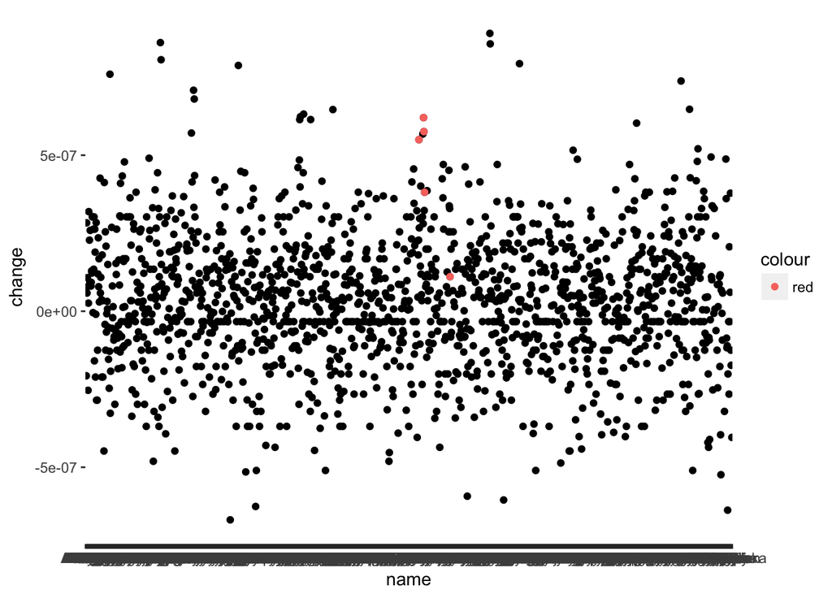

```r
#plot between changes in other female names and changes of ariel names
ggplot()+
  geom_point(data = gen_change, aes(x = name, y=change))+
  geom_point(data = ariels_change, aes(x=name, y= change,color='red'))
```

The analysis showed that Ariel names changes more than 81% of all names. That is, Ariel names were in the 81st percentile of change from 1988 to 1990.

This plot shows the change in the proportion of various names from 1988 to 1990. Names below the zero line decreased in relative popularity, while names above the zero line increased in relative popularity. The points on this plot (near the middle) which are red represent the change in popularity of different variations of the name “Ariel”. The important thing to note from this plot is that the Ariel names increased in popularity more than most other names.

The change in proportion of names was normalized by the count to avoid biasing such that more popular names (which will obviously have a higher raw change than less popular names) are not at an unfair advantage.

# Your Names

## Katie

```r
my <- babynames %>% filter(sex == "F")
ka <- my %>% filter(str_detect(name,"^Katie")) %>% filter(year == 1998 | year == 2015)
n1998 <- ka %>% filter(year == 1998)
n2015 <- ka %>% filter(year == 2015)
changeka <- left_join(n1998,n2015, by = "name") %>% mutate(diff = prop.x- prop.y) %>% count(wt = diff)
changeka
```

```
## # A tibble: 1 x 1
##         n
##     <dbl>
## 1 0.00138
```

```r
ka1981 <- my %>%filter(str_detect(name,"^Katie")) %>% filter(year == 1981 | year == 1998)
n1981 <- ka1981 %>% filter(year == 1981)
changeka2 <- left_join(n1981,n1998, by = "name") %>% mutate(diff = prop.x - prop.y) %>% count(wt = diff)
changeka2
```

```
## # A tibble: 1 x 1
##         n
##     <dbl>
## 1 0.00177
```

```r
all98<- filter(babynames,year == 1998)
all15<- filter(babynames,year == 2015)
```

My name Katie have the difference 0.00138 from 1998 to 2015, and have 0.00177 from 1981 to 1998.

## Ryan

For this analysis, year/gender was delt with by writing a conditional filter which filtered for the team member’s gender and birth year as it was filtering for his/her name. This was impossible to do for the whole data set, so the median year, 1997, was chosen as the representative.

The change in proportion of names was normalized here in a similar fashion as above.

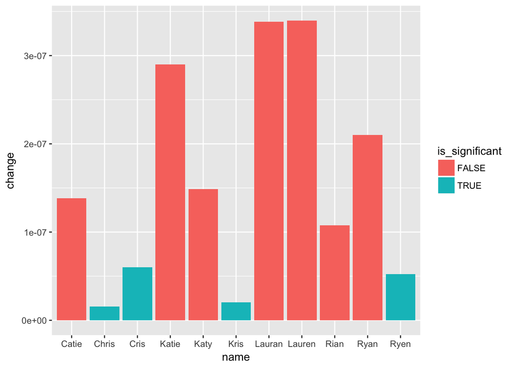

```r
rel_data_BY = babynames%>%filter(year == 1997)
rel_data_15 = babynames%>%filter(year == 2015)
rel_data_X = babynames%>%filter(year == 1979)

rel_data_change1 = left_join(rel_data_BY,rel_data_15,by = 'name')%>%filter(!is.na(year.y))%>%mutate(change = abs(prop.y-prop.x)/(n.x+n.y))
rel_data_change2 = left_join(rel_data_BY,rel_data_X,by = 'name')%>%filter(!is.na(year.y))%>%mutate(change = abs(prop.y-prop.x)/(n.x+n.y))




birth_year<-babynames%>%filter((str_detect(name,"R[yi][ae]n$") & year == 1997)& sex == 'M' |(str_detect(name,"Laur[ea]n+$") & year == 1996)& sex == 'F' | (str_detect(name,"[CK]atie$|[CK]aty$") & year == 1998)& sex == 'F'|(str_detect(name,"Chris$|Kris$|Cris$") & year == 1998)& sex == 'M'   )

year_2015<-babynames%>%filter((str_detect(name,"R[yi][ae]n$") & year == 2015)& sex == 'M' |(str_detect(name,"Laur[ea]n+$") & year == 2015)& sex == 'F' | (str_detect(name,"[CK]atie$|[CK]aty$") & year == 2015)& sex == 'F'|(str_detect(name,"Chris$|Kris$|Cris$") & year == 2015)& sex == 'M'   )

year_X<-babynames%>%filter((str_detect(name,"R[yi][ae]n$") & year == 1979)& sex == 'M' |(str_detect(name,"Laur[ea]n+$") & year == 1978)& sex == 'F' | (str_detect(name,"[CK]atie$|[CK]aty$") & year == 1980)& sex == 'F'|(str_detect(name,"Chris$|Kris$|Cris$") & year == 1980)& sex == 'M'   )



change1<-left_join(birth_year,year_2015,by="name")%>%filter(!is.na(year.y))

change1<-change1%>%mutate(change = abs(prop.y-prop.x)/(n.x+n.y))%>%mutate(is_significant = (change<1e-07))

change2<-left_join(birth_year,year_X,by='name')%>%filter(!is.na(year.y))
change2<-change2%>%mutate(change = abs(prop.y-prop.x)/(n.x+n.y))%>%mutate(is_significant = (change<1e-07))

ggplot(data = change1,aes(y=change,x=name,fill=is_significant))+
  geom_col()
```

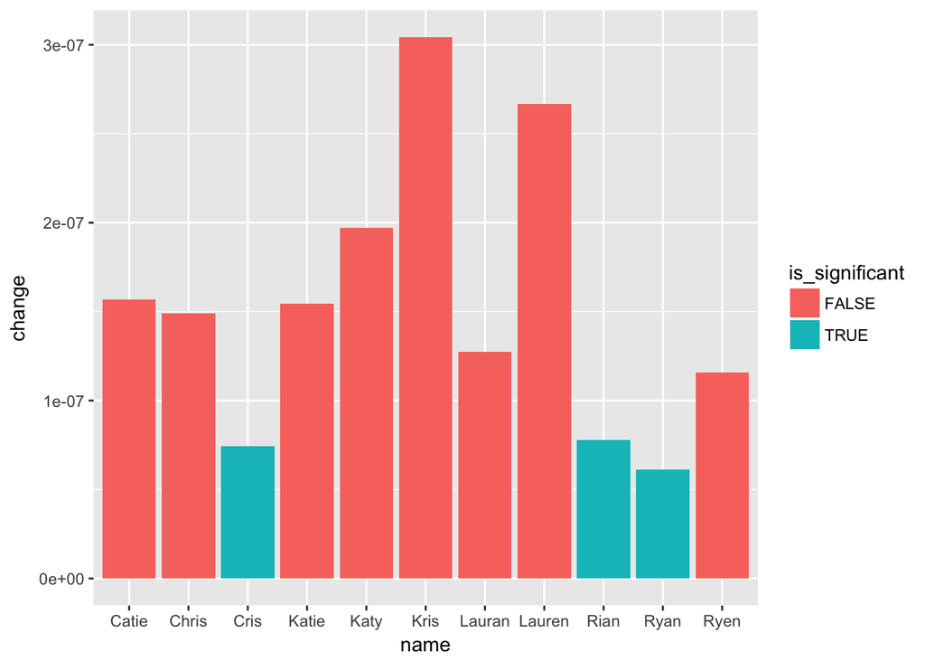

```r
ggplot(data = change2,aes(y=change,x=name,fill=is_significant))+
  geom_col()
```

```r
total_count1<-rel_data_change1%>%count()
ryan_count1<-rel_data_change1%>%filter(change<2.102606e-07)%>%count()
lauren_count1<-rel_data_change1%>%filter(change<3.397108e-07)%>%count()
katie_count1<-rel_data_change1%>%filter(change<2.900464e-07)%>%count()
chris_count1<-rel_data_change1%>%filter(change<1.573157e-08)%>%count()


total_count2<-rel_data_change2%>%count()
ryan_count2<-rel_data_change2%>%filter(change<6.125439e-08)%>%count()
lauren_count2<-rel_data_change2%>%filter(change<2.667051e-07)%>%count()
katie_count2<-rel_data_change2%>%filter(change<1.546803e-07)%>%count()
chris_count2<-rel_data_change2%>%filter(change<1.489500e-07)%>%count()




ryan_pct_change1 <- ryan_count1/total_count1
lauren_pct_change1 <- lauren_count1/total_count1
katie_pct_change1 <- katie_count1/total_count1
chris_pct_change1 <- chris_count1/total_count1


ryan_pct_change2 <- ryan_count2/total_count2
lauren_pct_change2 <- lauren_count2/total_count2
katie_pct_change2 <- katie_count2/total_count2
chris_pct_change2 <- chris_count2/total_count2


#Percentiles
ryan_pct_change1$n
```

```
## [1] 0.5444953
```

```r
lauren_pct_change1$n
```

```
## [1] 0.7830884
```

```r
katie_pct_change1$n
```

```
## [1] 0.7028668
```

```r
chris_pct_change1$n
```

```
## [1] 0.05232474
```

```r
ryan_pct_change2$n
```

```
## [1] 0.1694936
```

```r
lauren_pct_change2$n
```

```
## [1] 0.6345371
```

```r
katie_pct_change2$n
```

```
## [1] 0.4008888
```

```r
chris_pct_change2$n
```

```
## [1] 0.3915003
```

The perecntile of change from birth year to 2015 and birth year to birth year - X were computed as well. It seems like the name “Chris” had by far the lowest percent change from birth year to 2015, where the name“Lauren” had the highest. The name “Ryan” had the lowest change from year X to birth year, and the name “Lauren” had the highes percent change from birth year to 2015.

## Chris

```r
totalname2015<-babynames %>% filter(year==2015)
totalname1997<-babynames %>% filter(year==1997)
totalname1979<-babynames %>% filter(year==1979)
Chris2015<-totalname2015 %>% filter(str_detect(name, "^Chris?"))
Chris1997<-totalname1997 %>% filter(str_detect(name, "^Chris?"))
Chris1979<-totalname1979 %>% filter(str_detect(name, "^Chris?"))
```

```r
SUM1<-sum(Chris1997$n)/sum(totalname1997$n)-(sum(Chris1979$n)/sum(totalname1979$n))
SUM1
```

```
## [1] -0.01158509
```

```r
SUM2<-sum(Chris2015$n)/sum(totalname2015$n)-(sum(Chris1997$n)/sum(totalname1997$n))
SUM2
```

```
## [1] -0.009556007
```

I got stuck cause I am confuse what is the difference between the two percent change, so I calcualte the total name in each years first and find “Chris” shown number in exact years that we need, and I calculated it and I found, from 1979 to 1997 my name decrease like 1.1% and from I born to new era, 2015, my names occurs also decrease like 0.9%.

## Lauren

```r
LaurenProp1996 <- babynames %>% filter(str_detect(name, "Laur[ea]n$|Lor[eya]n$"), year==1996, sex=="F") %>% count(wt=prop)
LaurenProp2015 <- babynames %>% filter(str_detect(name, "Laur[ea]n$|Lor[eya]n$"), year==2015, sex=="F") %>% count(wt=prop)
ChangeInProp <- LaurenProp2015 - LaurenProp1996
ChangeInProp
```

```
##             nn
## 1 -0.005317505
```

The proportion of my name in 1996 was 0.00677 and in 2015 was 0.00146. The proportion of females named a version of Lauren decreased by 0.00531 from 1996 to 2015.

# Summary of Who did What

## Lauren

I completed each question described in the lab report. I relied heavily on str_detect() and count(). I also formatted the lab report in a way that combines each of our code for each question.

## Ryan

I created code which solved each of the four data science problems in the lab report. I created metrics which I thought best answered each question, and then created plots to best display the data as the answers.

## Chris

for all four question I used str_detect try to solve them, in my idividual part, I find the ratio and then I try to find the version and the chance that thoes two names occur in those years, 1973/1988/1990 and calculate the the ratio that we need. for the third question and the last question I got stuck at first,cause I thought made a graph is hard but when I asked and searching I did those two and find the relation that all we need.